**Data Science with**

[figure not shown]

R markdown version

# 1 **Tidy data**

> *Happy families are all alike; every unhappy family is unhappy in its own way. Leo Tolstoy*

It is impossible to predict how data may be presented to the analyst. Nearly each data set will have its own features, peculiarities and errors and we must be ready to work with any data shape. The task is then to transform data so that it is in a standardised format ready to be analysed using a system of choice, in our case `Python`.

The quote above applies to data sets as: Tidy data sets are all alike; every messy data set is messy in its own way.

Hadley Wickham in his paper [Tidy Data](https://www.jstatsoft.org/article/view/v059i10/v59i10.pdf) defines the three main qualities of tidy data which standardise the process of dealing with any data set:

1. Each variable forms a column.
2. Each observation forms a row.
3. Each type of observational unit forms a table.

Qualities 1 and 2 are crucial for adequate and ease of use of `Python` packages for visualisation and analysis. Quality 3 is important in order to organise the data but it might be necessary to unify tables with related information at some point for analysis. For example, we may have a table with information about the response to a medical intervention for patients and another table with demographic data. But at some point they might need to be joined for analysis.

These three qualities are what the end product of the data tidying process must possess.

*Messy data* is data which is not tidy.

Applying the tidy data criteria standardises the structure of a data set, making exploration and analysis of data easier and less error-prone.

# 2 **CASE STUDY.** Massachusetts Bay Transport Authority (MBTA) data from an excel file

[figure not shown]

[figure not shown]

[figure not shown]

Let us consider monthly transportation data in Boston, USA, consisting of monthly averages of weekday number of passengers (in thousands) by mode of transportation. A snapshot of part of the data (not all columns are included), in excel format, is below.

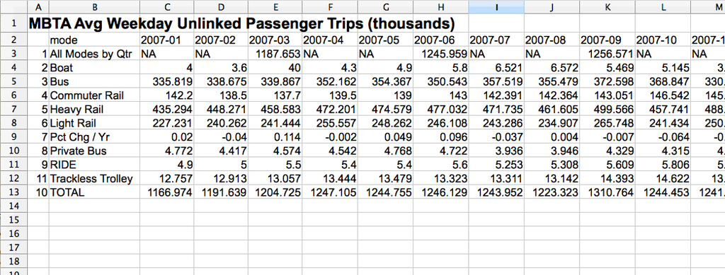

The variables in this study are mode of transportation, year, month, and weekday average number of trips.

Do this first:

```python
import pandas as pd
import numpy as np
import matplotlib.pyplot as plt
```

## 2.1 Importing the data

The first row in the excel sheet is a title, so we skip this row when reading the data in.

```python
#we skip the first row as it is a title, also the NA character is "NA", not blank space which is the default value
mbta = pd.read_excel("DataFiles/mbta.xlsx", skiprows = [0], na_values = "NA")
#show the first 5 rows
print(mbta.head())
```

```
##    Unnamed: 0              mode  2007-01   ...     2011-08   2011-09  2011-10
## 0           1  All Modes by Qtr      NaN   ...         NaN  1290.549      NaN
## 1           2              Boat    4.000   ...       6.733     5.003    4.484
## 2           3               Bus  335.819   ...     353.793   388.271  398.456
## 3           4     Commuter Rail  142.200   ...     130.616   136.901  128.720
## 4           5        Heavy Rail  435.294   ...     508.145   550.137  554.932
##
## [5 rows x 60 columns]
```

```python
#show the last 5 rows
print(mbta.tail())
```

```
##     Unnamed: 0               mode    ...      2011-09   2011-10
## 6            7       Pct Chg / Yr    ...        0.043     0.032
## 7            8        Private Bus    ...        2.843     2.967
## 8            9               RIDE    ...        8.318     8.598
## 9           10  Trackless Trolley    ...       12.332    12.297
## 10          11              TOTAL    ...     1348.754  1348.222
##
## [5 rows x 60 columns]
```

```python
#display all the column names
cols = list(mbta.columns.values)
print(cols)
```

```
## ['Unnamed: 0', 'mode', '2007-01', '2007-02', '2007-03', '2007-04', '2007-05', '2007-06', '2007-07', '2007-08', '2007-09', '2007-10', '2007-11', '2007-12', '2008-01', '2008-02', '2008-03', '2008-04', '2008-05', '2008-06', '2008-07', '2008-08', '2008-09', '2008-10', '2008-11', '2008-12', '2009-01',…
```

## 2.2 Tidying the data

As can be seen, the first column of `mbta`, unnamed in the original excel file and named `Unnamed: 0` by `Python`, simply gives the row number which is irrelevant, as rows are identified by mode of transportation, so we will exclude it. In some cases, not this particular data set, rows don’t have an identifier and so some sort of row id is needed. Also, the first row is a quarterly aggregation of the data and should not be mixed with monthly data by single mode of transportation. So we will exclude this first row of the data. The last row has totals by column so it will be excluded as well as it may cause errors to leave it. Row 7 has percentage change in the year, again a summary of the data which should not be in a tidy data set.

```python
#drop 1st, 7th and 11th rows and the first column
mbta.drop(index = [0,6,10], columns = 'Unnamed: 0', inplace = True)
print(mbta)
```

```
##                 mode  2007-01  2007-02   ...     2011-08  2011-09  2011-10
## 1               Boat    4.000    3.600   ...       6.733    5.003    4.484
## 2                Bus  335.819  338.675   ...     353.793  388.271  398.456
## 3      Commuter Rail  142.200  138.500   ...     130.616  136.901  128.720
## 4         Heavy Rail  435.294  448.271   ...     508.145  550.137  554.932
## 5         Light Rail  227.231  240.262   ...     220.164  244.949  237.768
## 7        Private Bus    4.772    4.417   ...       2.655    2.843    2.967
## 8               RIDE    4.900    5.000   ...       8.071    8.318    8.598
## 9  Trackless Trolley   12.757   12.913   ...      11.091   12.332   12.297
##
## [8 rows x 59 columns]
```

Continuing with the tidying up of the data, we recall that the variables in this experiment are mode of transportation, year, month and monthly average number of passengers. Therefore, all column names, except for the first one, `mode`, are values of year and month combined.

```python
# melt all column name values, except the first one (the index), into the "year_month" column with the corresponding values in the column "NrPassengers"
mbta2 = mbta.melt('mode', var_name = "year_month", value_name = "NrPassengers")
print(mbta2.head())
```

```
##             mode year_month  NrPassengers
## 0           Boat    2007-01         4.000
## 1            Bus    2007-01       335.819
## 2  Commuter Rail    2007-01       142.200
## 3     Heavy Rail    2007-01       435.294
## 4     Light Rail    2007-01       227.231
```

Next, the column `year_month` contains the values of two variables. We may want to keep the year in one column and month in another column.

```python
# new data frame with split value columns
new = mbta2['year_month'].str.split('-', n = 1, expand = True)
mbta3 = mbta2
```

```python
# making separate columns from new data frame
mbta3['year'] = new[0]
mbta3['month'] = new[1]
#drop year_month
mbta3.drop(columns = ['year_month'], inplace = True)
print(mbta3.head())
```

```
##             mode  NrPassengers  year month
## 0           Boat         4.000  2007    01
## 1            Bus       335.819  2007    01
## 2  Commuter Rail       142.200  2007    01
## 3     Heavy Rail       435.294  2007    01
## 4     Light Rail       227.231  2007    01
```

```python
print(mbta3.dtypes)
```

```
## mode             object
## NrPassengers    float64
## year             object
## month            object
## dtype: object
```

```python
#make columns year and month numeric
mbta3['year'] = pd.to_numeric(mbta3['year'])
mbta3['month'] = pd.to_numeric(mbta3['month'])
print(mbta3.dtypes)
```

```
## mode             object
## NrPassengers    float64
## year              int64
## month             int64
## dtype: object
```

```python
#create a column named day with 1s
mbta3 = mbta3.assign(day = 1)
#
mbta3['date'] = pd.to_datetime(mbta3[['year', 'month', 'day']])
print(mbta3.head())
```

```
##             mode  NrPassengers  year  month  day       date
## 0           Boat         4.000  2007      1    1 2007-01-01
## 1            Bus       335.819  2007      1    1 2007-01-01
## 2  Commuter Rail       142.200  2007      1    1 2007-01-01
## 3     Heavy Rail       435.294  2007      1    1 2007-01-01
## 4     Light Rail       227.231  2007      1    1 2007-01-01
```

```python
print(mbta3.dtypes)
```

```
## mode                    object
## NrPassengers           float64
## year                     int64
## month                    int64
## day                      int64
## date            datetime64[ns]
## dtype: object
```

The data is now tidy and ready to be explored.

Let us visualise the data.

We will mostly use the package `plotnine` to visualise the data as it is in line with the concept of tidy data.

For examples of visualisations using `pandas` see https://pandas.pydata.org/pandas-docs/version/0.22/visualization.html

## 2.3 `plotnine`

[figure not shown]

If you have used the package `ggplot2` in `R` you will have discovered high quality plots using minimal and simpler coding. `ggplot2` implements the so-called grammar of graphics.

[figure not shown]

> *“A grammar of graphics is a tool that enables us to concisely describe the components of a graphic. Such a grammar allows us to move beyond named graphics (e.g., the “scatterplot”) and gain insight into the deep structure that underlies statistical graphics. This article builds on Wilkinson, Anand, and Grossman (2005), describing extensions and refinements developed while building an open source implementation of the grammar of graphics for R, ggplot2.” H.Wickham in [‘A Layered Grammar of Graphics’.](http://vita.had.co.nz/papers/layered-grammar.pdf)*

The `Python` library `plotnine` is a Grammar-of-Graphics-inspired package written by Hassan Kibirige which brings the advantages of `ggplot2` to `Python`: less coding and more meaningful syntax.

Visit the official website of `plotnine` for more information https://plotnine.readthedocs.io/en/stable/index.html

The package documentation is in https://media.readthedocs.org/pdf/plotnine/latest/plotnine.pdf

For more examples of visualisations using `plotnine` see https://medium.com/@gscheithauer/data-visualization-in-python-like-in-rs-ggplot2-bc62f8debbf5

To install `plotnine` from the terminal (mac)

```r
# Using pip
$ pip install plotnine         # 1. should be sufficient for most
$ pip install 'plotnine[all]'  # 2. includes extra/optional packages

# Or using conda
$ conda install -c conda-forge plotnine
```

## 2.4 Using `plotnine`

- The function `ggplot()`, in the package `plotnine`, is used to visualise data.
- The basic use is

**( ggplot(myData, aes = (myMapping) + myGeometryLayer) )**

In order to access the functions in `plotnine` first we execute

```python
from plotnine import *
```

- In `plotnine` a plot is an object which can be re-called and modified.

## 2.5 Visualisation of `mbta` data

Let us explore the distribution of number of passengers by mode of transportation using boxplots.

First, we obtain the boxplots using `plotnine`. The tidy data set in `mbta3` is all what is needed.

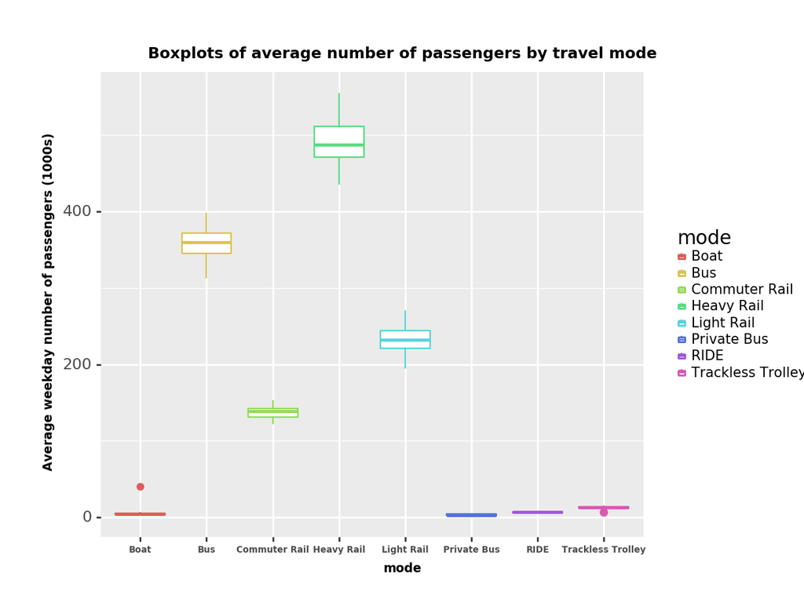

```python
from plotnine import *
#
fig = (
ggplot(mbta3, aes(x = 'mode', y = 'NrPassengers', color = 'mode'))
 + geom_boxplot()
 + ylab("Average weekday number of passengers (1000s)")
 + ggtitle("Boxplots of average number of passengers by travel mode")
 + theme(axis_text_x = element_text(rotation = 0, ha = 'center', size = 5, weight = 'bold'))
 + theme(axis_title = element_text(size = 7, weight='bold'))
 + theme(plot_title = element_text(size = 8.8, weight='bold'))
 + theme(legend_text = element_text(size = 7.8))
 + theme(legend_key_size = 5)
 + theme(subplots_adjust={'right': 0.8})
 )
print(fig)
```

Now let us obtain the same plot using `pandas` and `matplotlib`. We must place the data for each boxplot in a column. So, we will select `mode` and `NrPassengers`, indexed by `Date` and pivot the table so that the number of passengers by each mode is in a separate column.

```python
import matplotlib.pyplot as plt
aux_bp = mbta3[['date', 'mode', 'NrPassengers']]
aux_bp = pd.pivot_table(aux_bp, index= 'date', columns = 'mode', values = 'NrPassengers')
print(aux_bp.head())
```

```
## mode        Boat      Bus        ...          RIDE  Trackless Trolley
## date                             ...
## 2007-01-01   4.0  335.819        ...           4.9             12.757
## 2007-02-01   3.6  338.675        ...           5.0             12.913
## 2007-03-01  40.0  339.867        ...           5.5             13.057
## 2007-04-01   4.3  352.162        ...           5.4             13.444
## 2007-05-01   4.9  354.367        ...           5.4             13.479
##
## [5 rows x 8 columns]
```

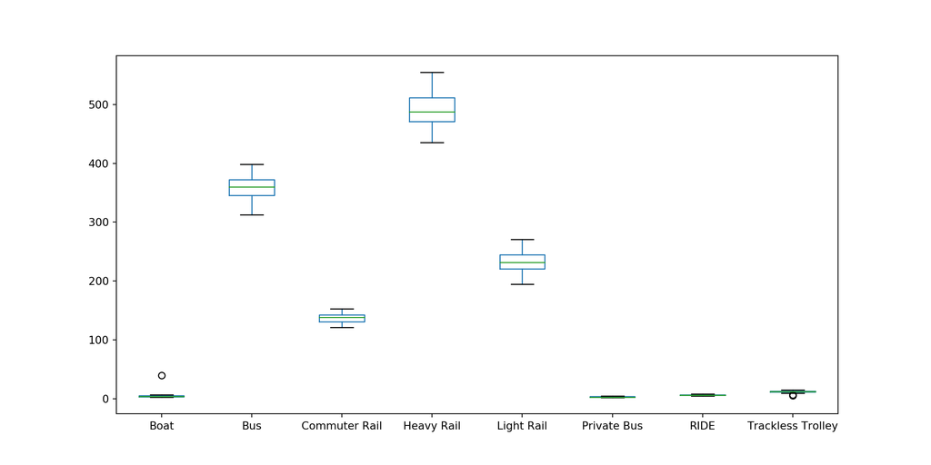

```python
aux_bp.plot.box()
plt.show()
```

We can see that most trips were made by heavy rail, bus, light rail and commuter rail, in descending order The number of passengers are on a different scale for boat, private bus and trackless trolley and their corresponding boxplots are difficult to visualise in the above plot so we will plot them separately below. We can nevertheless see some circles in the boat and trackless trolley boxplots indicating some unusual values.

Boxplot using `plotnine`

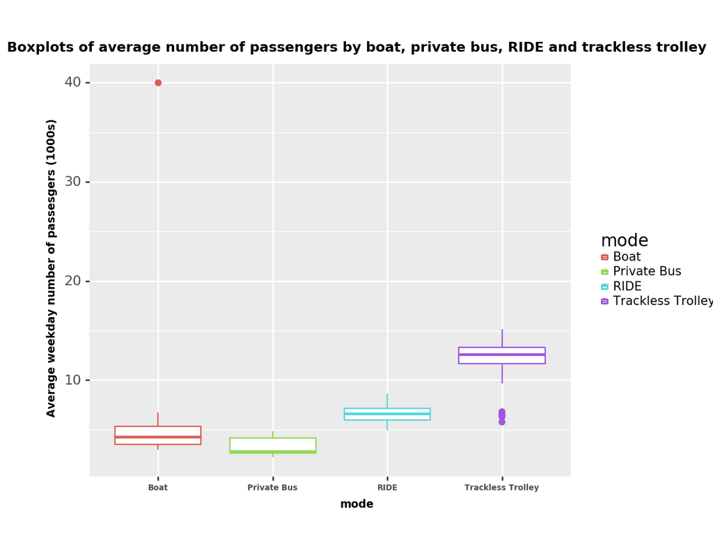

```python
aux = mbta3[ mbta3['mode'].isin(['Boat', 'Private Bus', 'RIDE', 'Trackless Trolley']) ]
#
fig = (
ggplot(aux, aes(x = 'mode' , y = 'NrPassengers', color = 'mode'))
 + geom_boxplot()
 + ylab("Average weekday number of passesgers (1000s)")
 + ggtitle("Boxplots of average number of passengers by boat, private bus, RIDE and trackless trolley")
 + theme(axis_text_x = element_text(rotation = 0, ha = 'center', size = 5, weight = 'bold'))
 + theme(axis_title = element_text(size = 7, weight = 'bold'))
 + theme(plot_title = element_text(size = 8.8, weight = 'bold'))
 + theme(legend_text = element_text(size = 7.8))
 + theme(legend_key_size = 5)
 + theme(subplots_adjust = {'right': 0.8})
 )
print(fig)
```

Boxplot using `pandas` and `matplotlib`

```python
#aux_bp1 contains the data only for boat, private bus, RIDE and trackless trolley.
aux_bp1 = aux_bp[ ['Boat', 'Private Bus', 'RIDE', 'Trackless Trolley'] ]
print(aux_bp1.head())
```

```
## mode        Boat  Private Bus  RIDE  Trackless Trolley
## date
## 2007-01-01   4.0        4.772   4.9             12.757
## 2007-02-01   3.6        4.417   5.0             12.913
## 2007-03-01  40.0        4.574   5.5             13.057
## 2007-04-01   4.3        4.542   5.4             13.444
## 2007-05-01   4.9        4.768   5.4             13.479
```

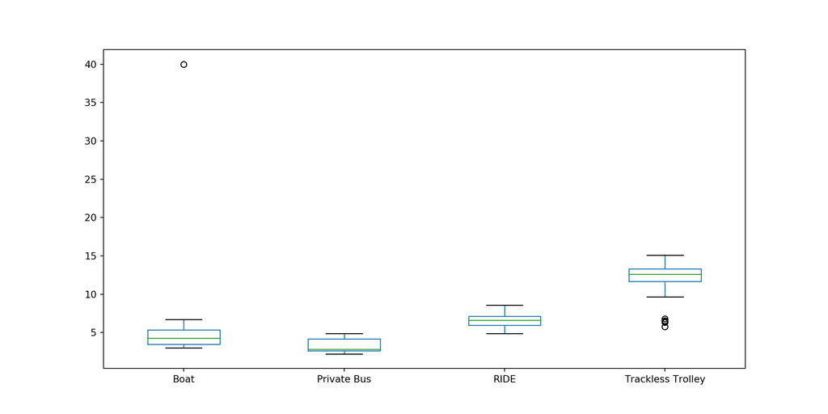

```python
aux_bp1.plot.box()
plt.show()
```

There is a very large observation for Boat. Let us find out when it was observed.

```python
#pb contains NrPassengers by boat only
pb = aux_bp1['Boat']
print( aux_bp1[ aux_bp1.Boat == max(pb) ])
```

```
## mode        Boat  Private Bus  RIDE  Trackless Trolley
## date
## 2007-03-01  40.0        4.574   5.5             13.057
```

The unusual observation occurred in March 2007. Looking at the distribution of the other values of number of passengers who traveled by boat

```python
pb1 = pb[pb < max(pb)]
print(pb1.describe())
```

```
## count    57.000000
## mean      4.455123
## std       1.134642
## min       2.985000
## 25%       3.488000
## 50%       4.285000
## 75%       5.189000
## max       6.733000
## Name: Boat, dtype: float64
```

and taking into account that no big event happened in Boston during that month, we conclude that it’s quite likely the person who entered the data added an extra zero. So, we change this value to 4. This should be checked with data originators and must be reported.

```python
mbta3.loc[ (mbta3['mode'] == 'Boat') & (mbta3['NrPassengers'] == 40) , 'NrPassengers' ] = 4
print(mbta3.loc[mbta3['mode'] == 'Boat', 'NrPassengers'].describe())
```

```
## count    58.000000
## mean      4.447276
## std       1.126232
## min       2.985000
## 25%       3.494000
## 50%       4.268000
## 75%       5.178000
## max       6.733000
## Name: NrPassengers, dtype: float64
```

Let us see the boxplots again.

Boxplots using `plotnine`

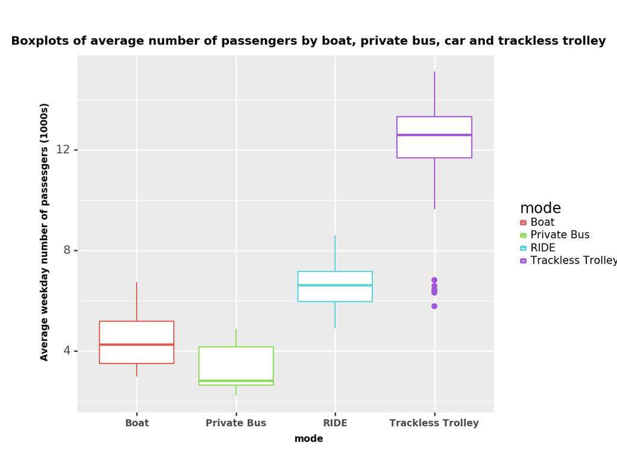

```python
aux = mbta3[ mbta3['mode'].isin(['Boat', 'Private Bus', 'RIDE', 'Trackless Trolley']) ]
#
fig = (
ggplot(aux, aes(x = 'mode' , y = 'NrPassengers', color = 'mode'))
 + geom_boxplot()
 + ylab("Average weekday number of passesgers (1000s)")
 + ggtitle("Boxplots of average number of passengers by boat, private bus, car and trackless trolley")
 + theme(axis_text_x = element_text(rotation = 0, ha = 'center', size = 7, weight = 'bold'))
 + theme(axis_title = element_text(size = 7, weight = 'bold'))
 + theme(plot_title = element_text(size = 8.8, weight = 'bold'))
 + theme(legend_text = element_text(size = 7.8))
 + theme(legend_key_size = 5)
 + theme(subplots_adjust = {'right': 0.8})
 )
#
print(fig)
```

Boxplots using `pandas` and `matplotlib`

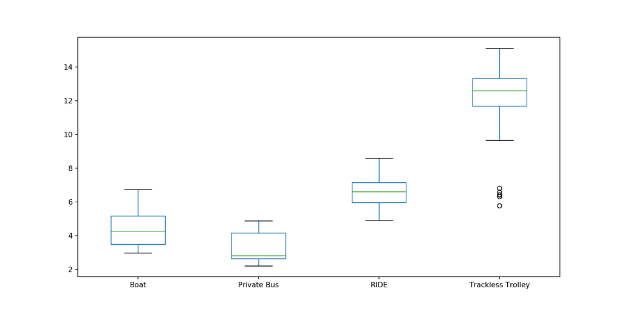

```python
import matplotlib.pyplot as plt
aux_bp = mbta3[['date', 'mode', 'NrPassengers']]
aux_bp = pd.pivot_table(aux_bp, index= 'date', columns = 'mode', values = 'NrPassengers')
#aux_bp1 contains the data only for boat, private bus, RIDE and trackless trolley.
aux_bp1 = aux_bp[ ['Boat', 'Private Bus', 'RIDE', 'Trackless Trolley'] ]
aux_bp1.plot.box()
plt.show()
```

There are some unusually low values for the number of passengers travelling by trackless trolley.

```python
#this is all the data for trackless trolley only
trtr = mbta3[mbta3['mode'] == 'Trackless Trolley']
aux = trtr.sort_values('NrPassengers')
print(aux.head(n=10))
```

```
##                   mode  NrPassengers  year  month  day       date
## 383  Trackless Trolley         5.777  2010     12    1 2010-12-01
## 351  Trackless Trolley         6.316  2010      8    1 2010-08-01
## 375  Trackless Trolley         6.415  2010     11    1 2010-11-01
## 359  Trackless Trolley         6.436  2010      9    1 2010-09-01
## 343  Trackless Trolley         6.584  2010      7    1 2010-07-01
## 367  Trackless Trolley         6.819  2010     10    1 2010-10-01
## 207  Trackless Trolley         9.645  2009      2    1 2009-02-01
## 439  Trackless Trolley        11.060  2011      7    1 2011-07-01
## 447  Trackless Trolley        11.091  2011      8    1 2011-08-01
## 391  Trackless Trolley        11.104  2011      1    1 2011-01-01
```

We note that all the unusually low observations for trackless trolley occurred in the second semester of 2010. So, it is likely there is a reason for that, the low observed averages are not errors. We should be aware of these values but not remove them for the moment.

Now that we have tidied up the data set we can visualise it. We will incorporate the time dimension in these plots.

First let us create a new variable, `date`.

```python
#create a column named day with 1s
mbta3 = mbta3.assign(day = 1)
mbta3['date'] = pd.to_datetime(mbta3[['year', 'month', 'day']])
print(mbta3.head())
```

```
##             mode  NrPassengers  year  month  day       date
## 0           Boat         4.000  2007      1    1 2007-01-01
## 1            Bus       335.819  2007      1    1 2007-01-01
## 2  Commuter Rail       142.200  2007      1    1 2007-01-01
## 3     Heavy Rail       435.294  2007      1    1 2007-01-01
## 4     Light Rail       227.231  2007      1    1 2007-01-01
```

```python
print(mbta3.dtypes)
```

```
## mode                    object
## NrPassengers           float64
## year                     int64
## month                    int64
## day                      int64
## date            datetime64[ns]
## dtype: object
```

Time plots in `plotnine`

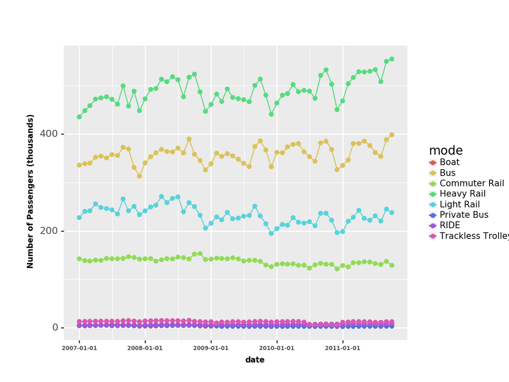

```python
fig = (
 ggplot(mbta3, aes(x = 'date', y = 'NrPassengers', color = 'mode'))
 +geom_line()
 + geom_point()
 + ylab("Number of Passengers (thousands)")
 + theme(axis_text_x = element_text(rotation = 0, ha = 'center', size = 5, weight = 'bold'))
 + theme(axis_title = element_text(size = 7, weight = 'bold'))
 + theme(plot_title = element_text(size = 8.8, weight = 'bold'))
 + theme(legend_text = element_text(size = 7.8))
 + theme(legend_key_size = 5)
 + theme(subplots_adjust = {'right': 0.8})
 )
  #
print(fig)
```

Time plot using `pandas` and `matplotlib`

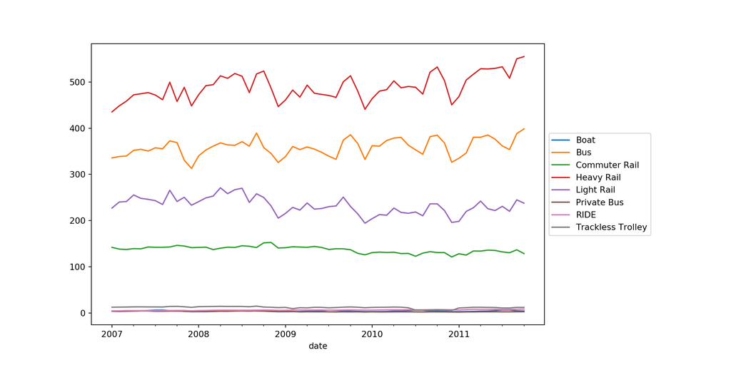

```python
pl = aux_bp.plot()
# Shrink current axis by 20%
box = pl.get_position()
pl.set_position([box.x0, box.y0, box.width * 0.8, box.height])
# Put a legend to the right of the current axis
pl.legend(loc='center left', bbox_to_anchor=(1, 0.5))
plt.show()
```

Again, note the very different scales for the data corresponding to the number of passengers travelling by boat, RIDE, trackless trolley and private bus. Due to that difference, it is difficult to visualise the time trends of these data. So, we will split the plots for those two subsets of mode of transportation.

Time plot using `plotnine`

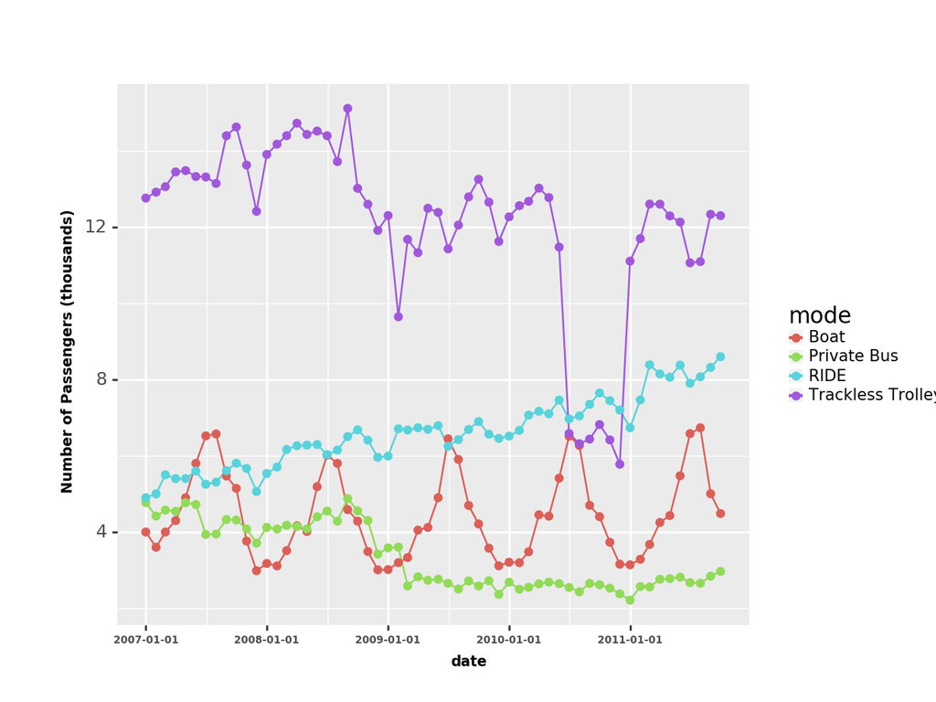

```python
#aux has already been defined but here it goes again
aux = mbta3[ mbta3['mode'].isin(['Boat', 'Private Bus', 'RIDE', 'Trackless Trolley']) ]
fig = (
ggplot(aux, aes(x = 'date', y = 'NrPassengers', color = 'mode'))
 + geom_line()
 + geom_point()
 + ylab("Number of Passengers (thousands)")
 + theme(axis_text_x = element_text(rotation = 0, ha = 'center', size = 5, weight = 'bold'))
 + theme(axis_title = element_text(size = 7, weight = 'bold'))
 + theme(plot_title = element_text(size = 8.8, weight = 'bold'))
 + theme(legend_text = element_text(size = 7.8))
 + theme(legend_key_size = 5)
 + theme(subplots_adjust = {'right': 0.8})
 )
 #
print(fig)
```

Time plot using `pandas` and `matplotlib`

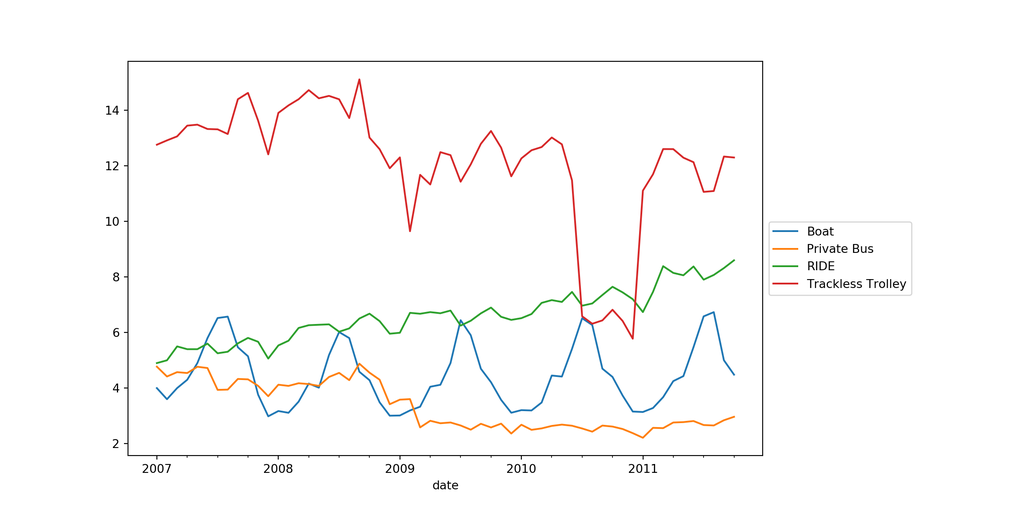

```python
#we have already defined aux_bp1
aux_bp1 = aux_bp[ ['Boat', 'Private Bus', 'RIDE', 'Trackless Trolley'] ]
pl = aux_bp1.plot()
# Shrink current axis by 20%
box = pl.get_position()
pl.set_position([box.x0, box.y0, box.width * 0.8, box.height])
# Put a legend to the right of the current axis
pl.legend(loc='center left', bbox_to_anchor=(1, 0.5))
plt.show()
```

Note the strong seasonal component in number of passengers travelling by boat and how the use of that mode of transportation is always highest during summer months and lowest during winter time. It was somewhat lower during 2008. The use of transportation provided by RIDE (for people with an impediment who cannot access other ways of transportation) seems to be steadily increasing during time. The use of private bus and trackless trolley had a sharp decrease since 2009 and something unusual made the use of trackless trolley dramatically decrease in the second half of 2010.

Now, let us explore the other modes of transportation.

Time plot using `plotnine`

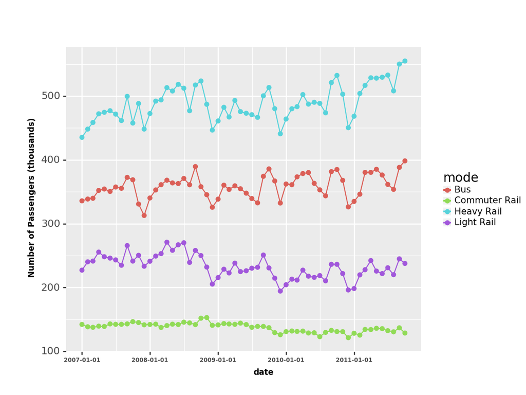

```python
#aux has already been defined but here it goes again
aux2 = mbta3[ mbta3['mode'].isin(['Bus', 'Commuter Rail', 'Heavy Rail', 'Light Rail']) ]
fig = (
ggplot(aux2, aes(x = 'date', y = 'NrPassengers', color = 'mode'))
 +  geom_line()
 +  geom_point()
 + ylab("Number of Passengers (thousands)")
 + theme(axis_text_x = element_text(rotation = 0, ha = 'center', size = 5, weight = 'bold'))
 + theme(axis_title = element_text(size = 7, weight = 'bold'))
 + theme(plot_title = element_text(size = 8.8, weight = 'bold'))
 + theme(legend_text = element_text(size = 7.8))
 + theme(legend_key_size = 5)
 + theme(subplots_adjust = {'right': 0.8})
)
#
print(fig)
```

Time plots in `pandas` and `matplotlib`

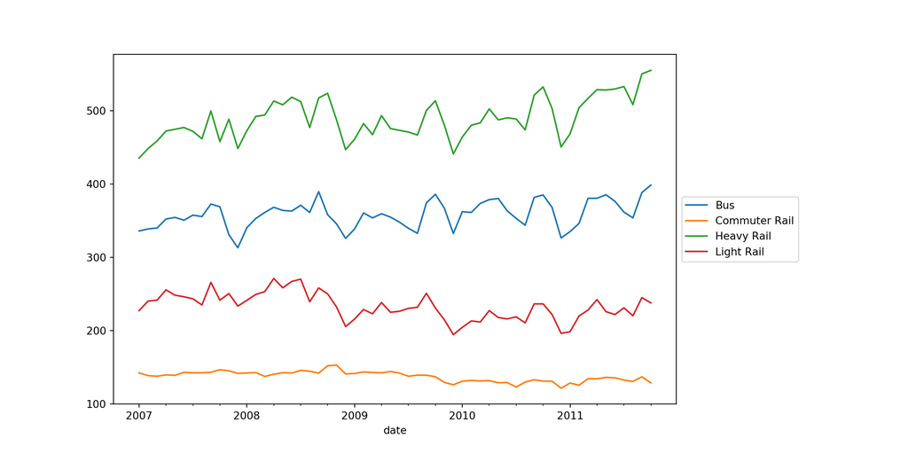

```python
aux_bp2 = aux_bp[ ['Bus', 'Commuter Rail', 'Heavy Rail', 'Light Rail'] ]
pl = aux_bp2.plot()
# Shrink current axis by 20%
box = pl.get_position()
pl.set_position([box.x0, box.y0, box.width * 0.8, box.height])
# Put a legend to the right of the current axis
pl.legend(loc='center left', bbox_to_anchor=(1, 0.5))
plt.show()
```

We observe that the number of passengers travelling by light and commuter rail has decreased since 2009, whilst there seems to be an upwards trend on number of passengers travelling by heavy rail and perhaps by bus as well.